# Week 5 Day 1 Homework

```r
library(tidyverse)
library(CodeClanData)
rev <- qb_revenue_breakdown
sales <- qb_monthly_sales
competitors <- qb_competitors
device_data <- qb_device_data

col_scheme <- c("#E89FE9", "#50434F", "#B6A7B5", "#F9A472", "#BD7040")
```

# MVP

## Part 1

### Question 1

Take the data in the dataset qb_revenue_breakdown and make a stacked bar chart showing the sources of revenue across the two years in the dataset.

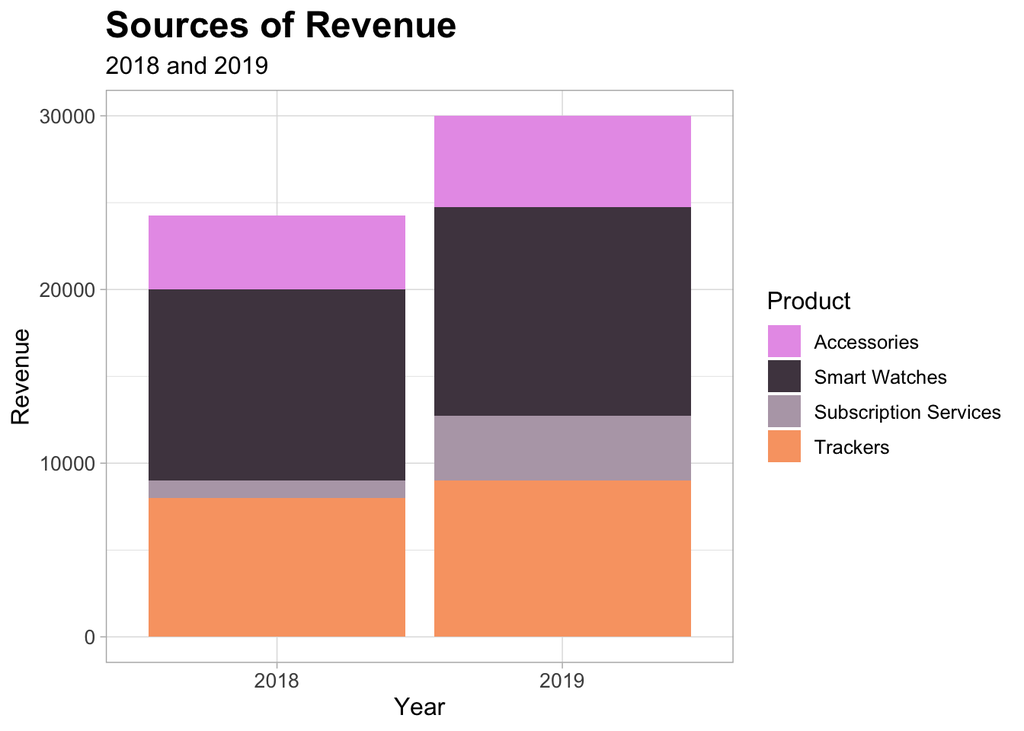

```r
ggplot(rev) +
  aes(x = Year, y = Revenue, fill = Product) +
  geom_bar(stat = "identity") +
  labs(title = "Sources of Revenue", subtitle = "2018 and 2019") +
  scale_fill_manual(values = col_scheme) +
  theme_light() +
  theme(text = element_text(size = 12),
        axis.text = element_text(size = 10),
        plot.title = element_text(size = 18, face = "bold")
        )
```

### Question 2

Make a line chart showing monthly sales of the “flagship product” - the ‘KwikBit Unit 1’ - over the last year. This data is inside qb_monthly_sales, but you will need to use filter() or subset() (base R).

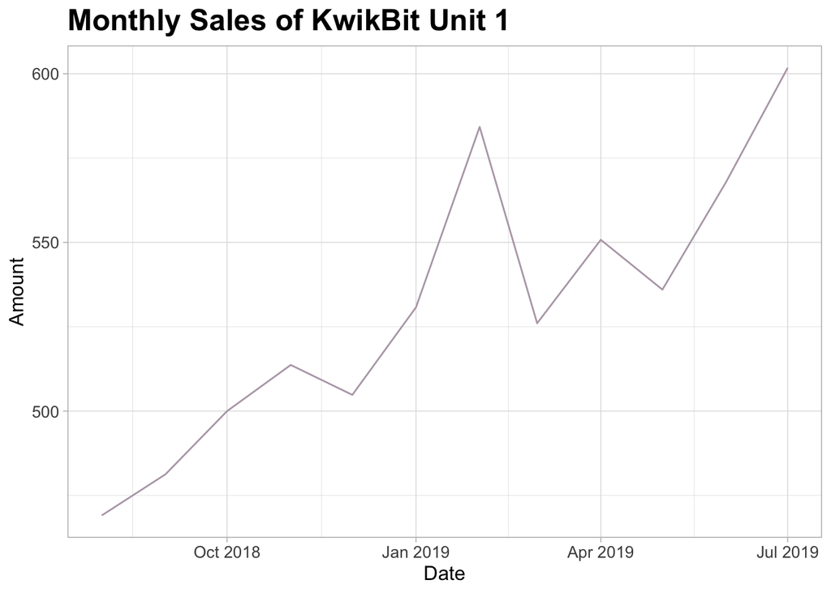

```r
ggplot(sales %>% filter(Cashflow == "Kwikbit Unit 1 Sales")) +
  aes(x = Date, y = Amount) +
  geom_line(colour = "#B6A7B5") +
  labs(title = "Monthly Sales of KwikBit Unit 1") +
  theme_light() +
  theme(text = element_text(size = 12),
        axis.text = element_text(size = 10),
        plot.title = element_text(size = 18, face = "bold")
        )
```

### Question 3

Make a line chart showing monthly revenue and costs over the last year. This data is also in qb_monthly_sales.

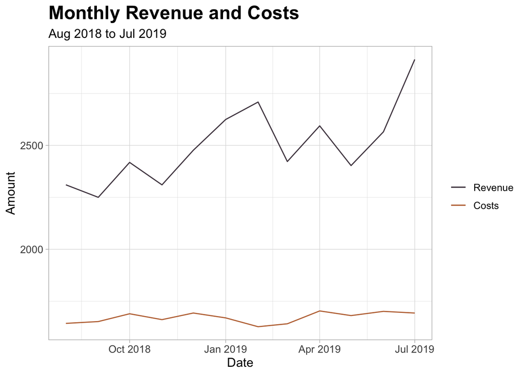

```r
legend_colors <- c("Revenue" = "#50434F", "Costs" = "#BD7040")

ggplot() +
  aes(x = Date, y = Amount) +
  geom_line(data = (sales %>% filter(Cashflow == "Total Revenue")),
            aes(color = "Revenue")) +
  geom_line(data = (sales %>% filter(Cashflow == "Cost")),
            aes(color = "Costs")) +
  labs(title = "Monthly Revenue and Costs", subtitle = "Aug 2018 to Jul 2019") +
  scale_color_manual(values = legend_colors, name="") +
  theme_light() +
  theme(legend.title = element_blank(),
        text = element_text(size = 12),
        axis.text = element_text(size = 10),
        plot.title = element_text(size = 18, face = "bold"))
```

```r
# do somethig about date along x axis
```

### Question 4

Show annual sales of personal fitness trackers over the last 5 years broken down by company as a ribbon plot (use geom_area). This data is in qb_competitors.

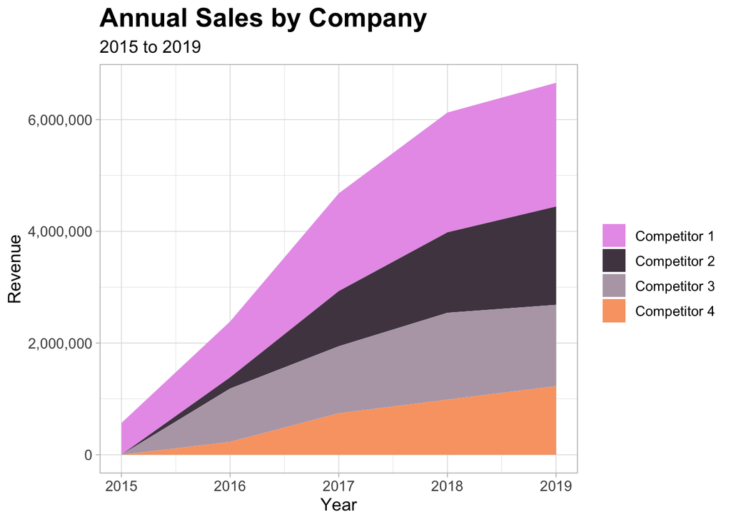

```r
ggplot(competitors) +
  aes(x = Year, y = Revenue, fill = Company) +
  geom_area() +
  scale_y_continuous(labels = scales::comma) +
  labs(title = "Annual Sales by Company", subtitle = "2015 to 2019") +
  scale_fill_manual(values = col_scheme) +
  theme_light() +
  theme(legend.title = element_blank(),
        text = element_text(size = 12),
        axis.text = element_text(size = 10),
        plot.title = element_text(size = 18, face = "bold"))
```

## Question 5

Now show the sales from the four competitors as a line graph. Include an extra layer that shows the data points used to make the lines.

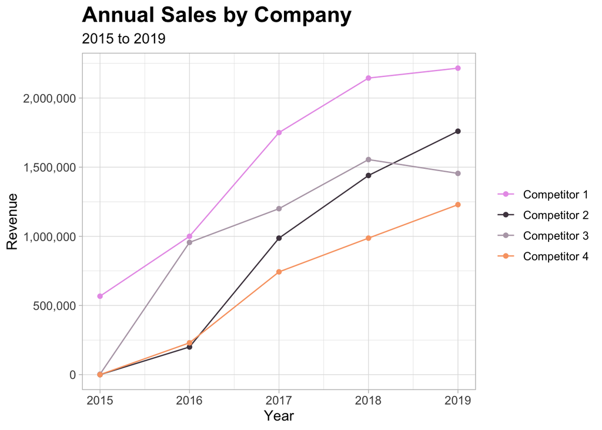

```r
ggplot(competitors) +
  aes(Year, Revenue) +
  geom_line(aes(colour = Company)) +
  geom_point(aes(colour = Company)) +
  scale_y_continuous(labels = scales::comma) +
  labs(title = "Annual Sales by Company", subtitle = "2015 to 2019") +
  scale_colour_manual(values = col_scheme) +
  theme_light() +
  theme(legend.title = element_blank(),
        text = element_text(size = 12),
        axis.text = element_text(size = 10),
        plot.title = element_text(size = 18, face = "bold"))
```

### Question 6

Now the company wants to compare the number of steps that their device counts vs. their competitors. Make a line graph of the number of steps throughout time, and use faceting to compare between companies and people. The data for this is in qb_device_data.

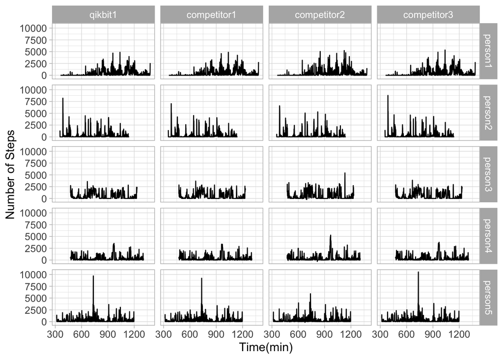

```r
device_data %>%
  mutate(time_mins = ((hours * 60) + mins)) %>%
ggplot() +
  aes(x = time_mins, y = counts) +
  geom_line() +
  facet_grid(id ~ device) +
  labs(x = "Time(min)", y = "Number of Steps") +
  theme_light() +
  theme(legend.title = element_blank(),
        text = element_text(size = 12),
        axis.text = element_text(size = 10),
        plot.title = element_text(size = 18, face = "bold"))
```